# Risk Factor Analysis

## Outcome Variable

**Outcome Variable:** whz

## Predictor Variables

**Intervention Variable:** mhtcm

**Adjustment Set:**

- arm
- W_mage
- W_fage
- meducyrs
- feducyrs
- single
- W_gagebrth
- W_birthwt
- W_birthlen
- vagbrth
- delta_W_mage
- delta_W_fage
- delta_meducyrs
- delta_feducyrs
- delta_single
- delta_W_gagebrth
- delta_W_birthwt
- delta_W_birthlen
- delta_vagbrth

## Stratifying Variables

The analysis was stratified on these variable(s):

- agecat
- studyid
- country

## Data Summary

| agecat | studyid | country | mhtcm | n_cell | n |
| --- | --- | --- | --- | --- | --- |
| 6 months | COHORTS | GUATEMALA | >=155 cm | 117 | 946 |
| 6 months | COHORTS | GUATEMALA | <151 cm | 632 | 946 |
| 6 months | COHORTS | GUATEMALA | [151-155) cm | 197 | 946 |
| 6 months | COHORTS | INDIA | >=155 cm | 541 | 1819 |
| 6 months | COHORTS | INDIA | <151 cm | 791 | 1819 |
| 6 months | COHORTS | INDIA | [151-155) cm | 487 | 1819 |
| 6 months | COHORTS | PHILIPPINES | >=155 cm | 560 | 2706 |
| 6 months | COHORTS | PHILIPPINES | <151 cm | 1368 | 2706 |
| 6 months | COHORTS | PHILIPPINES | [151-155) cm | 778 | 2706 |
| 6 months | Guatemala BSC | GUATEMALA | >=155 cm | 36 | 231 |
| 6 months | Guatemala BSC | GUATEMALA | <151 cm | 141 | 231 |
| 6 months | Guatemala BSC | GUATEMALA | [151-155) cm | 54 | 231 |
| 6 months | Keneba | GAMBIA | >=155 cm | 1568 | 1877 |
| 6 months | Keneba | GAMBIA | <151 cm | 67 | 1877 |
| 6 months | Keneba | GAMBIA | [151-155) cm | 242 | 1877 |
| 6 months | LCNI-5 | MALAWI | >=155 cm | 513 | 836 |
| 6 months | LCNI-5 | MALAWI | <151 cm | 131 | 836 |
| 6 months | LCNI-5 | MALAWI | [151-155) cm | 192 | 836 |
| 6 months | MAL-ED | BANGLADESH | >=155 cm | 24 | 241 |
| 6 months | MAL-ED | BANGLADESH | <151 cm | 156 | 241 |
| 6 months | MAL-ED | BANGLADESH | [151-155) cm | 61 | 241 |
| 6 months | MAL-ED | BRAZIL | >=155 cm | 121 | 209 |
| 6 months | MAL-ED | BRAZIL | <151 cm | 51 | 209 |
| 6 months | MAL-ED | BRAZIL | [151-155) cm | 37 | 209 |
| 6 months | MAL-ED | INDIA | >=155 cm | 55 | 235 |
| 6 months | MAL-ED | INDIA | <151 cm | 112 | 235 |
| 6 months | MAL-ED | INDIA | [151-155) cm | 68 | 235 |
| 6 months | MAL-ED | NEPAL | >=155 cm | 41 | 236 |
| 6 months | MAL-ED | NEPAL | <151 cm | 132 | 236 |
| 6 months | MAL-ED | NEPAL | [151-155) cm | 63 | 236 |

[output cut: 87 more lines]

The following strata were considered:

- agecat: 24 months, studyid: COHORTS, country: GUATEMALA
- agecat: 24 months, studyid: COHORTS, country: INDIA
- agecat: 24 months, studyid: COHORTS, country: PHILIPPINES
- agecat: 24 months, studyid: Keneba, country: GAMBIA
- agecat: 24 months, studyid: LCNI-5, country: MALAWI
- agecat: 24 months, studyid: MAL-ED, country: BANGLADESH
- agecat: 24 months, studyid: MAL-ED, country: BRAZIL
- agecat: 24 months, studyid: MAL-ED, country: INDIA
- agecat: 24 months, studyid: MAL-ED, country: NEPAL
- agecat: 24 months, studyid: MAL-ED, country: PERU
- agecat: 24 months, studyid: MAL-ED, country: SOUTH AFRICA
- agecat: 24 months, studyid: MAL-ED, country: TANZANIA, UNITED REPUBLIC OF
- agecat: 24 months, studyid: NIH-Birth, country: BANGLADESH
- agecat: 24 months, studyid: NIH-Crypto, country: BANGLADESH
- agecat: 24 months, studyid: PROBIT, country: BELARUS
- agecat: 24 months, studyid: PROVIDE, country: BANGLADESH
- agecat: 24 months, studyid: TanzaniaChild2, country: TANZANIA, UNITED REPUBLIC OF
- agecat: 24 months, studyid: ZVITAMBO, country: ZIMBABWE
- agecat: 6 months, studyid: COHORTS, country: GUATEMALA
- agecat: 6 months, studyid: COHORTS, country: INDIA
- agecat: 6 months, studyid: COHORTS, country: PHILIPPINES
- agecat: 6 months, studyid: Guatemala BSC, country: GUATEMALA
- agecat: 6 months, studyid: Keneba, country: GAMBIA
- agecat: 6 months, studyid: LCNI-5, country: MALAWI
- agecat: 6 months, studyid: MAL-ED, country: BANGLADESH
- agecat: 6 months, studyid: MAL-ED, country: BRAZIL
- agecat: 6 months, studyid: MAL-ED, country: INDIA
- agecat: 6 months, studyid: MAL-ED, country: NEPAL
- agecat: 6 months, studyid: MAL-ED, country: PERU
- agecat: 6 months, studyid: MAL-ED, country: SOUTH AFRICA
- agecat: 6 months, studyid: MAL-ED, country: TANZANIA, UNITED REPUBLIC OF
- agecat: 6 months, studyid: NIH-Birth, country: BANGLADESH
- agecat: 6 months, studyid: NIH-Crypto, country: BANGLADESH
- agecat: 6 months, studyid: PROBIT, country: BELARUS
- agecat: 6 months, studyid: PROVIDE, country: BANGLADESH
- agecat: 6 months, studyid: SAS-CompFeed, country: INDIA
- agecat: 6 months, studyid: SAS-FoodSuppl, country: INDIA
- agecat: 6 months, studyid: TanzaniaChild2, country: TANZANIA, UNITED REPUBLIC OF
- agecat: 6 months, studyid: ZVITAMBO, country: ZIMBABWE

### Dropped Strata

Some strata were dropped due to rare outcomes:

- agecat: 24 months, studyid: TanzaniaChild2, country: TANZANIA, UNITED REPUBLIC OF

## Methods Detail

We’re interested in the causal parameters $E[Y_a]$ for all values of $a \in \mathcal{A}$. These parameters represent the mean outcome if, possibly contrary to fact, we intervened to set all units to have $A=a$. Under the randomization and positivity assumptions, these are identified by the statistical parameters $\psi_a=E_W[E_{Y|A,W}(Y|A=a,W)]$. In addition, we’re interested in the mean of $Y$, $E[Y]$ under no intervention (the observed mean). We will estimate these parameters by using SuperLearner to fit the relevant likelihood factors – $E_{Y|A,W}(Y|A=a,W)$ and $p(A=a|W)$, and then updating our likelihood fit using a joint TMLE.

For unadjusted analyses ($W=\{\}$), initial likelihoods were estimated using Lrnr_glm to estimate the simple $E(Y|A)$ and Lrnr_mean to estimate $p(A)$. For adjusted analyses, a small library containing Lrnr_glmnet, Lrnr_xgboost, and Lrnr_mean was used.

Having estimated these parameters, we will then use the delta method to estimate relative risks and attributable risks relative to a prespecified baseline level of $A$.

# Results Detail

## Results Plots

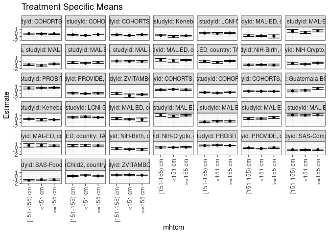

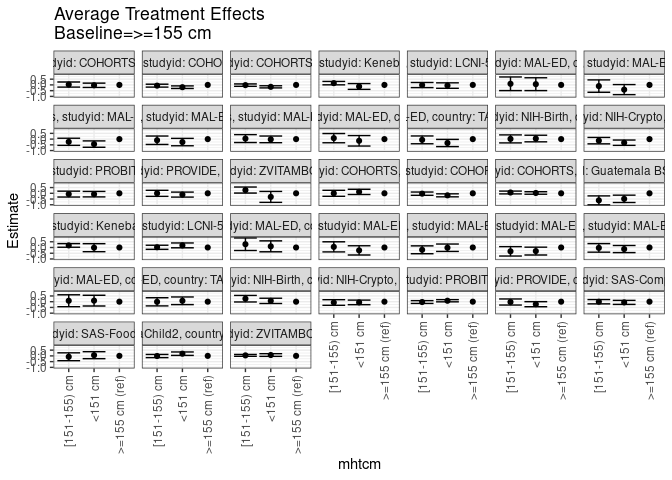

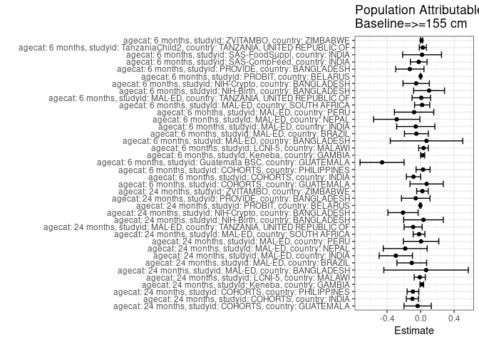

## Results Table

### Parameter: TSM

| agecat | studyid | country | intervention_level | baseline_level | estimate | ci_lower | ci_upper |
| --- | --- | --- | --- | --- | --- | --- | --- |
| 6 months | COHORTS | GUATEMALA | >=155 cm | NA | 0.1211484 | -0.0890831 | 0.3313799 |
| 6 months | COHORTS | GUATEMALA | <151 cm | NA | 0.2450676 | 0.1550551 | 0.3350801 |
| 6 months | COHORTS | GUATEMALA | [151-155) cm | NA | 0.1213200 | -0.0357611 | 0.2784010 |
| 6 months | COHORTS | INDIA | >=155 cm | NA | -0.5920359 | -0.6939800 | -0.4900919 |
| 6 months | COHORTS | INDIA | <151 cm | NA | -0.7686630 | -0.8487036 | -0.6886224 |
| 6 months | COHORTS | INDIA | [151-155) cm | NA | -0.6233538 | -0.7253068 | -0.5214008 |
| 6 months | COHORTS | PHILIPPINES | >=155 cm | NA | -0.3229844 | -0.4157971 | -0.2301718 |
| 6 months | COHORTS | PHILIPPINES | <151 cm | NA | -0.2946796 | -0.3511259 | -0.2382332 |
| 6 months | COHORTS | PHILIPPINES | [151-155) cm | NA | -0.2537148 | -0.3342357 | -0.1731939 |
| 6 months | Guatemala BSC | GUATEMALA | >=155 cm | NA | 0.4339313 | 0.1584552 | 0.7094073 |
| 6 months | Guatemala BSC | GUATEMALA | <151 cm | NA | -0.0490047 | -0.2084147 | 0.1104054 |
| 6 months | Guatemala BSC | GUATEMALA | [151-155) cm | NA | -0.1816102 | -0.4548241 | 0.0916037 |
| 6 months | Keneba | GAMBIA | >=155 cm | NA | -0.2300530 | -0.2881826 | -0.1719234 |
| 6 months | Keneba | GAMBIA | <151 cm | NA | -0.2457586 | -0.5908818 | 0.0993646 |
| 6 months | Keneba | GAMBIA | [151-155) cm | NA | -0.0485442 | -0.1957023 | 0.0986138 |
| 6 months | LCNI-5 | MALAWI | >=155 cm | NA | 0.4169795 | 0.3276231 | 0.5063358 |
| 6 months | LCNI-5 | MALAWI | <151 cm | NA | 0.6020036 | 0.4112603 | 0.7927470 |
| 6 months | LCNI-5 | MALAWI | [151-155) cm | NA | 0.4360006 | 0.2818019 | 0.5901994 |
| 6 months | MAL-ED | BANGLADESH | >=155 cm | NA | -0.2077003 | -0.6613925 | 0.2459919 |
| 6 months | MAL-ED | BANGLADESH | <151 cm | NA | -0.1069527 | -0.2541302 | 0.0402248 |
| 6 months | MAL-ED | BANGLADESH | [151-155) cm | NA | 0.0772178 | -0.2282554 | 0.3826910 |
| 6 months | MAL-ED | BRAZIL | >=155 cm | NA | 1.0226075 | 0.7994491 | 1.2457659 |
| 6 months | MAL-ED | BRAZIL | <151 cm | NA | 0.7714002 | 0.4367720 | 1.1060285 |
| 6 months | MAL-ED | BRAZIL | [151-155) cm | NA | 1.0778038 | 0.6982811 | 1.4573265 |
| 6 months | MAL-ED | INDIA | >=155 cm | NA | -0.6451831 | -0.8991668 | -0.3911994 |
| 6 months | MAL-ED | INDIA | <151 cm | NA | -0.6665986 | -0.8629482 | -0.4702490 |
| 6 months | MAL-ED | INDIA | [151-155) cm | NA | -0.8460216 | -1.0721122 | -0.6199309 |
| 6 months | MAL-ED | NEPAL | >=155 cm | NA | 0.3959204 | 0.0974517 | 0.6943892 |
| 6 months | MAL-ED | NEPAL | <151 cm | NA | 0.0830672 | -0.0845869 | 0.2507214 |
| 6 months | MAL-ED | NEPAL | [151-155) cm | NA | 0.0619854 | -0.2181160 | 0.3420867 |

[output cut: 84 more lines]

### Parameter: E(Y)

| agecat | studyid | country | intervention_level | baseline_level | estimate | ci_lower | ci_upper |
| --- | --- | --- | --- | --- | --- | --- | --- |
| 6 months | COHORTS | GUATEMALA | NA | NA | 0.1926004 | 0.1207018 | 0.2644990 |
| 6 months | COHORTS | INDIA | NA | NA | -0.6768114 | -0.7301317 | -0.6234912 |
| 6 months | COHORTS | PHILIPPINES | NA | NA | -0.2938433 | -0.3352064 | -0.2524802 |
| 6 months | Guatemala BSC | GUATEMALA | NA | NA | -0.0255916 | -0.1507513 | 0.0995680 |
| 6 months | Keneba | GAMBIA | NA | NA | -0.2053991 | -0.2588843 | -0.1519138 |
| 6 months | LCNI-5 | MALAWI | NA | NA | 0.4515550 | 0.3802638 | 0.5228463 |
| 6 months | MAL-ED | BANGLADESH | NA | NA | -0.1376763 | -0.2664642 | -0.0088885 |
| 6 months | MAL-ED | BRAZIL | NA | NA | 0.9720774 | 0.8078144 | 1.1363403 |
| 6 months | MAL-ED | INDIA | NA | NA | -0.7034149 | -0.8300527 | -0.5767771 |
| 6 months | MAL-ED | NEPAL | NA | NA | 0.1104308 | -0.0208643 | 0.2417259 |
| 6 months | MAL-ED | PERU | NA | NA | 1.0548591 | 0.9328922 | 1.1768259 |
| 6 months | MAL-ED | SOUTH AFRICA | NA | NA | 0.5291499 | 0.3751396 | 0.6831602 |
| 6 months | MAL-ED | TANZANIA, UNITED REPUBLIC OF | NA | NA | 0.5362213 | 0.4049390 | 0.6675036 |
| 6 months | NIH-Birth | BANGLADESH | NA | NA | -0.4474038 | -0.5378167 | -0.3569909 |
| 6 months | NIH-Crypto | BANGLADESH | NA | NA | 0.0297622 | -0.0491685 | 0.1086930 |
| 6 months | PROBIT | BELARUS | NA | NA | 0.5782032 | 0.5194935 | 0.6369129 |
| 6 months | PROVIDE | BANGLADESH | NA | NA | -0.1987071 | -0.2815473 | -0.1158669 |
| 6 months | SAS-CompFeed | INDIA | NA | NA | -0.6426305 | -0.7702214 | -0.5150396 |
| 6 months | SAS-FoodSuppl | INDIA | NA | NA | -1.0053826 | -1.1208084 | -0.8899568 |
| 6 months | TanzaniaChild2 | TANZANIA, UNITED REPUBLIC OF | NA | NA | 0.0787757 | 0.0256721 | 0.1318793 |
| 6 months | ZVITAMBO | ZIMBABWE | NA | NA | 0.2948466 | 0.2673139 | 0.3223793 |
| 24 months | COHORTS | GUATEMALA | NA | NA | -0.2844036 | -0.3405555 | -0.2282517 |
| 24 months | COHORTS | INDIA | NA | NA | -0.5719523 | -0.6185009 | -0.5254037 |
| 24 months | COHORTS | PHILIPPINES | NA | NA | -0.6099592 | -0.6467541 | -0.5731643 |
| 24 months | Keneba | GAMBIA | NA | NA | -0.8101717 | -0.8592463 | -0.7610970 |
| 24 months | LCNI-5 | MALAWI | NA | NA | -0.0468717 | -0.1290135 | 0.0352701 |
| 24 months | MAL-ED | BANGLADESH | NA | NA | -0.8192925 | -0.9412667 | -0.6973182 |
| 24 months | MAL-ED | BRAZIL | NA | NA | 0.4626233 | 0.2567495 | 0.6684971 |
| 24 months | MAL-ED | INDIA | NA | NA | -0.9519248 | -1.0678488 | -0.8360007 |
| 24 months | MAL-ED | NEPAL | NA | NA | -0.3749123 | -0.4886073 | -0.2612173 |
| 24 months | MAL-ED | PERU | NA | NA | 0.1111982 | -0.0118399 | 0.2342362 |
| 24 months | MAL-ED | SOUTH AFRICA | NA | NA | 0.3916417 | 0.2704414 | 0.5128421 |
| 24 months | MAL-ED | TANZANIA, UNITED REPUBLIC OF | NA | NA | 0.0547975 | -0.0703378 | 0.1799328 |
| 24 months | NIH-Birth | BANGLADESH | NA | NA | -0.9115790 | -1.0095022 | -0.8136559 |
| 24 months | NIH-Crypto | BANGLADESH | NA | NA | -0.6103502 | -0.7050157 | -0.5156847 |
| 24 months | PROBIT | BELARUS | NA | NA | 0.6991214 | 0.5821715 | 0.8160713 |
| 24 months | PROVIDE | BANGLADESH | NA | NA | -0.8914360 | -0.9741797 | -0.8086923 |
| 24 months | ZVITAMBO | ZIMBABWE | NA | NA | -1.1712534 | -1.2800940 | -1.0624128 |

### Parameter: ATE

| agecat | studyid | country | intervention_level | baseline_level | estimate | ci_lower | ci_upper |
| --- | --- | --- | --- | --- | --- | --- | --- |
| 6 months | COHORTS | GUATEMALA | >=155 cm | >=155 cm | 0.0000000 | 0.0000000 | 0.0000000 |
| 6 months | COHORTS | GUATEMALA | <151 cm | >=155 cm | 0.1239192 | -0.1033749 | 0.3512132 |
| 6 months | COHORTS | GUATEMALA | [151-155) cm | >=155 cm | 0.0001716 | -0.2617255 | 0.2620686 |
| 6 months | COHORTS | INDIA | >=155 cm | >=155 cm | 0.0000000 | 0.0000000 | 0.0000000 |
| 6 months | COHORTS | INDIA | <151 cm | >=155 cm | -0.1766271 | -0.3060238 | -0.0472303 |
| 6 months | COHORTS | INDIA | [151-155) cm | >=155 cm | -0.0313178 | -0.1752280 | 0.1125923 |
| 6 months | COHORTS | PHILIPPINES | >=155 cm | >=155 cm | 0.0000000 | 0.0000000 | 0.0000000 |
| 6 months | COHORTS | PHILIPPINES | <151 cm | >=155 cm | 0.0283049 | -0.0799288 | 0.1365385 |
| 6 months | COHORTS | PHILIPPINES | [151-155) cm | >=155 cm | 0.0692696 | -0.0532644 | 0.1918036 |
| 6 months | Guatemala BSC | GUATEMALA | >=155 cm | >=155 cm | 0.0000000 | 0.0000000 | 0.0000000 |
| 6 months | Guatemala BSC | GUATEMALA | <151 cm | >=155 cm | -0.4829359 | -0.8021367 | -0.1637352 |
| 6 months | Guatemala BSC | GUATEMALA | [151-155) cm | >=155 cm | -0.6155415 | -1.0051876 | -0.2258954 |
| 6 months | Keneba | GAMBIA | >=155 cm | >=155 cm | 0.0000000 | 0.0000000 | 0.0000000 |
| 6 months | Keneba | GAMBIA | <151 cm | >=155 cm | -0.0157056 | -0.3653548 | 0.3339436 |
| 6 months | Keneba | GAMBIA | [151-155) cm | >=155 cm | 0.1815088 | 0.0237028 | 0.3393148 |
| 6 months | LCNI-5 | MALAWI | >=155 cm | >=155 cm | 0.0000000 | 0.0000000 | 0.0000000 |
| 6 months | LCNI-5 | MALAWI | <151 cm | >=155 cm | 0.1850242 | -0.0256968 | 0.3957452 |
| 6 months | LCNI-5 | MALAWI | [151-155) cm | >=155 cm | 0.0190212 | -0.1593395 | 0.1973818 |
| 6 months | MAL-ED | BANGLADESH | >=155 cm | >=155 cm | 0.0000000 | 0.0000000 | 0.0000000 |
| 6 months | MAL-ED | BANGLADESH | <151 cm | >=155 cm | 0.1007476 | -0.3757447 | 0.5772399 |
| 6 months | MAL-ED | BANGLADESH | [151-155) cm | >=155 cm | 0.2849181 | -0.2629363 | 0.8327726 |
| 6 months | MAL-ED | BRAZIL | >=155 cm | >=155 cm | 0.0000000 | 0.0000000 | 0.0000000 |
| 6 months | MAL-ED | BRAZIL | <151 cm | >=155 cm | -0.2512073 | -0.6540739 | 0.1516593 |
| 6 months | MAL-ED | BRAZIL | [151-155) cm | >=155 cm | 0.0551963 | -0.3854305 | 0.4958230 |
| 6 months | MAL-ED | INDIA | >=155 cm | >=155 cm | 0.0000000 | 0.0000000 | 0.0000000 |
| 6 months | MAL-ED | INDIA | <151 cm | >=155 cm | -0.0214156 | -0.3450935 | 0.3022623 |
| 6 months | MAL-ED | INDIA | [151-155) cm | >=155 cm | -0.2008385 | -0.5433711 | 0.1416942 |
| 6 months | MAL-ED | NEPAL | >=155 cm | >=155 cm | 0.0000000 | 0.0000000 | 0.0000000 |
| 6 months | MAL-ED | NEPAL | <151 cm | >=155 cm | -0.3128532 | -0.6545201 | 0.0288137 |
| 6 months | MAL-ED | NEPAL | [151-155) cm | >=155 cm | -0.3339350 | -0.7422412 | 0.0743711 |

[output cut: 84 more lines]

### Parameter: PAR

| agecat | studyid | country | intervention_level | baseline_level | estimate | ci_lower | ci_upper |
| --- | --- | --- | --- | --- | --- | --- | --- |
| 6 months | COHORTS | GUATEMALA | >=155 cm | NA | 0.0714520 | -0.1269028 | 0.2698068 |
| 6 months | COHORTS | INDIA | >=155 cm | NA | -0.0847755 | -0.1697354 | 0.0001844 |
| 6 months | COHORTS | PHILIPPINES | >=155 cm | NA | 0.0291411 | -0.0539819 | 0.1122641 |
| 6 months | Guatemala BSC | GUATEMALA | >=155 cm | NA | -0.4595229 | -0.7221766 | -0.1968692 |
| 6 months | Keneba | GAMBIA | >=155 cm | NA | 0.0246539 | 0.0004914 | 0.0488164 |
| 6 months | LCNI-5 | MALAWI | >=155 cm | NA | 0.0345756 | -0.0227432 | 0.0918943 |
| 6 months | MAL-ED | BANGLADESH | >=155 cm | NA | 0.0700240 | -0.3618103 | 0.5018582 |
| 6 months | MAL-ED | BRAZIL | >=155 cm | NA | -0.0505302 | -0.1929349 | 0.0918746 |
| 6 months | MAL-ED | INDIA | >=155 cm | NA | -0.0582318 | -0.2858857 | 0.1694220 |
| 6 months | MAL-ED | NEPAL | >=155 cm | NA | -0.2854896 | -0.5610170 | -0.0099623 |
| 6 months | MAL-ED | PERU | >=155 cm | NA | -0.0776451 | -0.3119437 | 0.1566535 |
| 6 months | MAL-ED | SOUTH AFRICA | >=155 cm | NA | 0.0181142 | -0.0721509 | 0.1083792 |
| 6 months | MAL-ED | TANZANIA, UNITED REPUBLIC OF | >=155 cm | NA | 0.0077649 | -0.1026663 | 0.1181960 |
| 6 months | NIH-Birth | BANGLADESH | >=155 cm | NA | 0.1009071 | -0.0831100 | 0.2849242 |
| 6 months | NIH-Crypto | BANGLADESH | >=155 cm | NA | -0.0532041 | -0.2107252 | 0.1043171 |
| 6 months | PROBIT | BELARUS | >=155 cm | NA | -0.0000555 | -0.0041135 | 0.0040024 |
| 6 months | PROVIDE | BANGLADESH | >=155 cm | NA | -0.1283477 | -0.2965538 | 0.0398583 |
| 6 months | SAS-CompFeed | INDIA | >=155 cm | NA | -0.0228170 | -0.1223296 | 0.0766957 |
| 6 months | SAS-FoodSuppl | INDIA | >=155 cm | NA | 0.0170675 | -0.2149218 | 0.2490568 |
| 6 months | TanzaniaChild2 | TANZANIA, UNITED REPUBLIC OF | >=155 cm | NA | 0.0260828 | -0.0161621 | 0.0683277 |
| 6 months | ZVITAMBO | ZIMBABWE | >=155 cm | NA | 0.0106130 | -0.0036327 | 0.0248586 |
| 24 months | COHORTS | GUATEMALA | >=155 cm | NA | -0.0357571 | -0.1983158 | 0.1268015 |
| 24 months | COHORTS | INDIA | >=155 cm | NA | -0.0982180 | -0.1704838 | -0.0259521 |
| 24 months | COHORTS | PHILIPPINES | >=155 cm | NA | -0.0916552 | -0.1613303 | -0.0219801 |
| 24 months | Keneba | GAMBIA | >=155 cm | NA | 0.0139401 | -0.0080480 | 0.0359282 |
| 24 months | LCNI-5 | MALAWI | >=155 cm | NA | -0.0100475 | -0.0763576 | 0.0562625 |
| 24 months | MAL-ED | BANGLADESH | >=155 cm | NA | 0.0653940 | -0.4385191 | 0.5693072 |
| 24 months | MAL-ED | BRAZIL | >=155 cm | NA | -0.1057582 | -0.2829831 | 0.0714666 |
| 24 months | MAL-ED | INDIA | >=155 cm | NA | -0.2959479 | -0.4943801 | -0.0975157 |
| 24 months | MAL-ED | NEPAL | >=155 cm | NA | -0.1840209 | -0.4460986 | 0.0780568 |
| 24 months | MAL-ED | PERU | >=155 cm | NA | 0.0054440 | -0.2056418 | 0.2165298 |
| 24 months | MAL-ED | SOUTH AFRICA | >=155 cm | NA | -0.0189549 | -0.0890095 | 0.0510996 |
| 24 months | MAL-ED | TANZANIA, UNITED REPUBLIC OF | >=155 cm | NA | -0.0889058 | -0.1965610 | 0.0187493 |
| 24 months | NIH-Birth | BANGLADESH | >=155 cm | NA | 0.0341237 | -0.2017836 | 0.2700310 |
| 24 months | NIH-Crypto | BANGLADESH | >=155 cm | NA | -0.2096911 | -0.3895235 | -0.0298587 |
| 24 months | PROBIT | BELARUS | >=155 cm | NA | -0.0028157 | -0.0109816 | 0.0053501 |
| 24 months | PROVIDE | BANGLADESH | >=155 cm | NA | -0.0583005 | -0.2281404 | 0.1115394 |
| 24 months | ZVITAMBO | ZIMBABWE | >=155 cm | NA | 0.0217152 | -0.0470539 | 0.0904844 |